# Cluserting Objetivo 3

Joel Porcar

2025-05-27

```r
library(knitr)
library(cluster)
library(FactoMineR)
library(factoextra)
library(NbClust)
library(clValid)
library(dplyr)
```

```r
library(ggplot2)
library(lubridate)
library(gridExtra)
library(ggsci)
library(tidyr)
```

Cargamos los datos de precios de energía y de importaciones/exportaciones.

```r
datosPrecio <- read.csv("C:/Users/joelp/OrdenadorJoelPorcar/Documentos/2nCienciadeDatos/Proyecto II/Joel Porcar/precios_energia.csv")
datosImpExp <- read.csv2("C:/Users/joelp/OrdenadorJoelPorcar/Documentos/2nCienciadeDatos/Proyecto II/Joel Porcar/datosImportacionExportacion20232024.csv",
                         header = FALSE, stringsAsFactors = FALSE)
```

Se procede a limpiar los datos, cambiar nombres de columnas y unificar los datasets para el análisis como hemos hecho antes.

```r
# Limpieza inicial de datosImpExp
datosImpExp <- datosImpExp[, -c(1, 3, 4)]  # Eliminar columnas no necesarias
colnames(datosImpExp) <- as.character(unlist(datosImpExp[1, ]))
datosImpExp <- datosImpExp[-1, ]
datosImpExp <- datosImpExp[!grepl("programada P48", datosImpExp$name), ]

# Procesamiento de datosPrecio
colnames(datosPrecio)[colnames(datosPrecio) == "Precio....MWh."] <- "Precio"
datosPrecio <- datosPrecio %>%
  mutate(
    Fecha = as.Date(Fecha, format = "%d/%m/%Y"),
    Hora = as.numeric(Hora)
  ) %>%
  select(Fecha, Hora, Precio)

# Procesamiento de datosImpExp
datosImpExp <- datosImpExp %>%
  mutate(
    datetime = ymd_hms(datetime),
    Hora = as.numeric(substr(format(datetime, "%H:%M:%S"), 1, 2)),
    Fecha = as.Date(format(datetime, "%d/%m/%Y"), format = "%d/%m/%Y"),
    value = as.numeric(value),

    # Identificar país y tipo de operación
    pais = case_when(
      grepl("Francia", name) ~ "Francia",
      grepl("Marruecos", name) ~ "Marruecos",
      grepl("Portugal", name) ~ "Portugal",
      grepl("Andorra", name) ~ "Andorra",
      TRUE ~ "Otro"
    ),
    tipo = ifelse(grepl("Exportación", name), "Exportación", "Importación"),
    energia_MWh = value
  ) %>%
  filter(year(datetime) == 2024) %>%
  select(Fecha, Hora, pais, tipo, energia_MWh)
datosCompletos <- datosImpExp %>%
  left_join(datosPrecio, by = c("Fecha", "Hora"))
datos_modelo <- datosCompletos %>%

  # Primero separamos importaciones y exportaciones
  pivot_wider(names_from = tipo, values_from = energia_MWh,
              values_fn = sum, values_fill = 0) %>%
  # Luego agrupamos por fecha y calculamos los promedios y sumas
  group_by(Fecha) %>%
  summarise(Precio_medio = mean(Precio, na.rm = TRUE),
            Importación = sum(Importación, na.rm = TRUE),
            Exportación = sum(Exportación, na.rm = TRUE))
```

Se realiza un análisis jerárquico usando el método de Ward y se determina un número de clusters inicial.

```r
mat_s <- datos_modelo %>%
  select(Precio_medio, Importación, Exportación) %>%
  drop_na() %>%
  scale()

diss_mat <- dist(mat_s, method = "euclidean")
clust1 <- hclust(diss_mat, method = "ward.D2")
grupos1 <- cutree(clust1, k = 3)
table(grupos1)
```

```
## grupos1
##   1   2   3
## 139  85 142
```

Determinación del número óptimo de clusters (Ward) Se exploran los métodos Silhouette y WSS para determinar el número adecuado de clusters. Aunque 2 clusters parecen óptimos, se elige 3 para tener mayor segmentación sin sobreajustar.

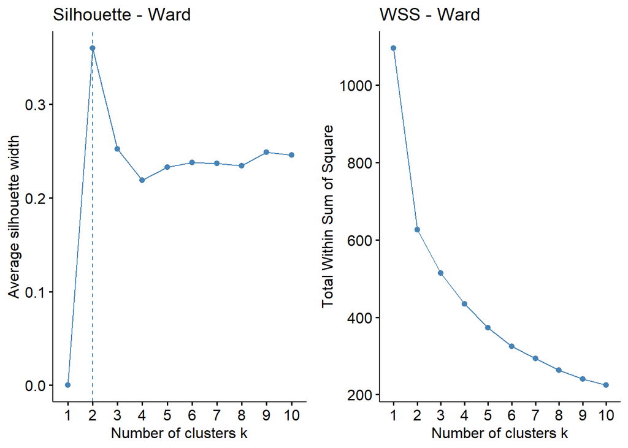

```r
p1 <- fviz_nbclust(mat_s, FUNcluster = hcut, method = "silhouette",
                   hc_method = "ward.D2", k.max = 10, diss = diss_mat) +
  labs(title = "Silhouette - Ward")
p2 <- fviz_nbclust(mat_s, FUNcluster = hcut, method = "wss",
                   hc_method = "ward.D2", k.max = 10, diss = diss_mat) +
  labs(title = "WSS - Ward")

grid.arrange(p1, p2, nrow = 1)
```

Se realiza un análisis de clustering mediante el algoritmo K-means con 3 clusters.

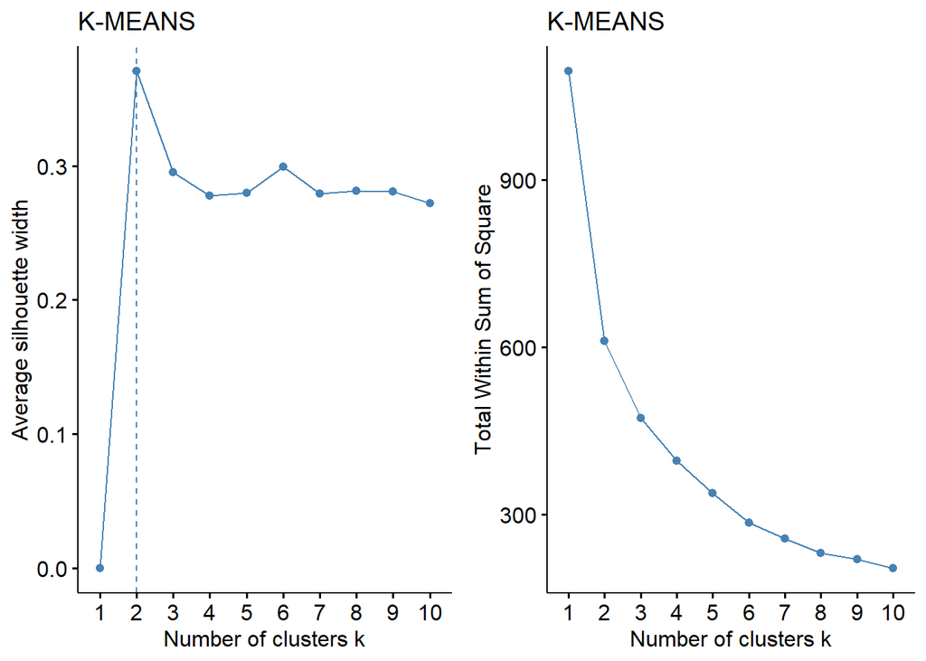

```r
# Silhouette y WSS
p1 <- fviz_nbclust(mat_s, FUNcluster = kmeans, method = "silhouette", k.max = 10) + labs(title = "K-MEANS")
p2 <- fviz_nbclust(mat_s, FUNcluster = kmeans, method = "wss", k.max = 10) + labs(title = "K-MEANS")
grid.arrange(p1, p2, nrow = 1)
```

```r
# K-means con 3 clusters
set.seed(100)
clust3 <- kmeans(mat_s, centers = 3, nstart = 30)
table(clust3$cluster)
```

```
##
##   1   2   3
## 105 120 141
```

K-meodides Clustering Se realiza un análisis alternativo con el método K-medoides (PAM) y se compara con los resultados anteriores.

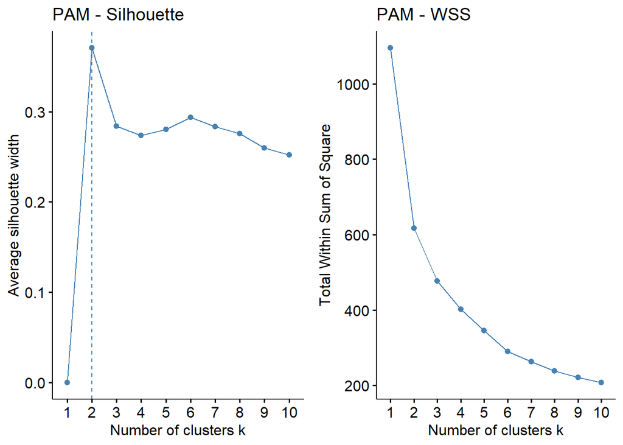

```r
# PAM clustering
p3 <- fviz_nbclust(mat_s, FUNcluster = pam, method = "silhouette", k.max = 10) + labs(title = "PAM - Silhouette")
p4 <- fviz_nbclust(mat_s, FUNcluster = pam, method = "wss", k.max = 10) + labs(title = "PAM - WSS")
grid.arrange(p3, p4, nrow = 1)
```

```r
clust4 <- pam(diss_mat, k = 3)
table(clust4$clustering)
```

```
##
##   1   2   3
## 146 136  84
```

Asignación de clusters y evaluación con Silhouette Se visualiza la calidad del clustering mediante el gráfico de Silhouette para los métodos Ward, K-means y PAM.

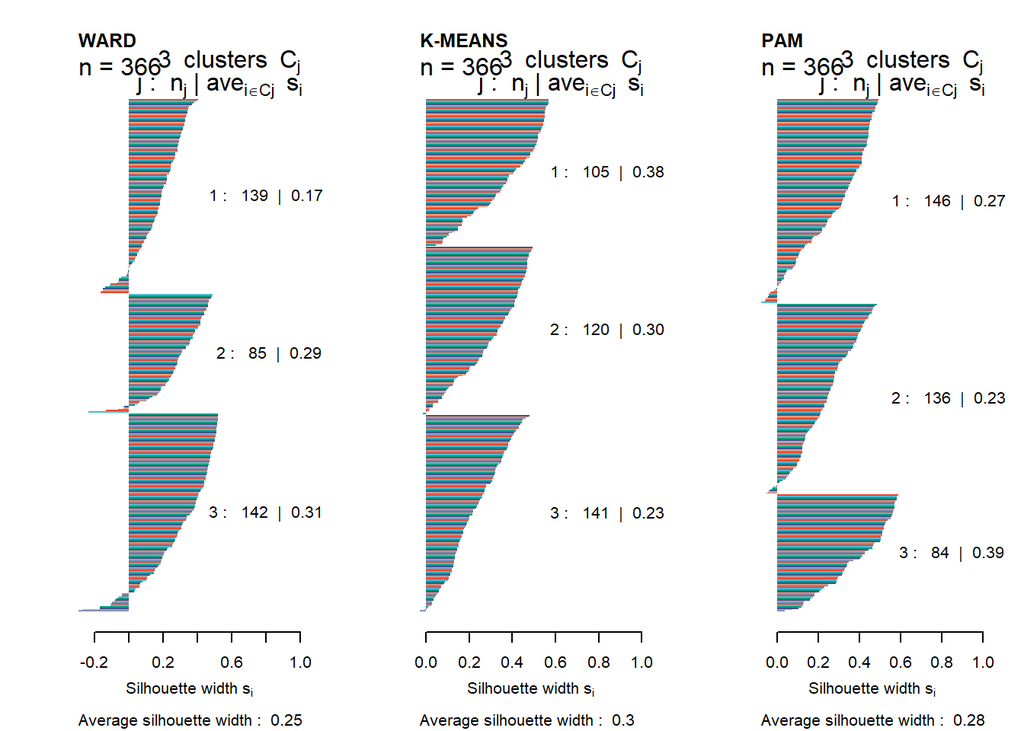

```r
# Silhouette plots
colores <- pal_npg("nrc")(6)
par(mfrow = c(1,3))
plot(silhouette(grupos1, diss_mat), col=colores, border=NA, main = "WARD")
plot(silhouette(clust3$cluster, diss_mat), col=colores, border=NA, main = "K-MEANS")
plot(silhouette(clust4$clustering, diss_mat), col=colores, border=NA, main = "PAM")
```

```r
par(mfrow = c(1,3))
```

Vemos que el mejor es el de K-means porque el coeficiente de silhouette es el más grande.

Preparación para análisis por cluster Se filtran los datos para eliminar NAs y se asignan los clusters obtenidos con K-means.

```r
datos_modelo <- datosCompletos %>%
  pivot_wider(names_from = tipo, values_from = energia_MWh,
              values_fn = sum, values_fill = 0) %>%
  group_by(Fecha) %>%
  summarise(
    Precio_medio = mean(Precio, na.rm = TRUE),
    Importación = sum(Importación, na.rm = TRUE),
    Exportación = sum(Exportación, na.rm = TRUE)
  )
```

Resumen estadístico por cluster Se calcula un resumen con la media del precio, importaciones y exportaciones por cluster para facilitar la interpretación.

```r
datos_cluster <- datos_modelo %>%
  select(Importación, Exportación, Precio_medio) %>%
  drop_na() %>%
  scale()

set.seed(123)
kmeans_res <- kmeans(datos_cluster, centers = 3, nstart = 25)
```

```r
# Primero filtra los datos sin NA para las columnas usadas
datos_modelo_completo <- datos_modelo %>%
  filter(!is.na(Precio_medio) & !is.na(Importación) & !is.na(Exportación))

datos_modelo_completo$cluster_kmeans <- factor(kmeans_res$cluster)

# Resumen por cluster usando cluster_kmeans en datos_modelo_completo
resumen_cluster <- datos_modelo_completo %>%
  group_by(cluster_kmeans) %>%
  summarise(
    Dias = n(),
    Precio_medio = mean(Precio_medio, na.rm = TRUE),
    Importacion_media = mean(Importación, na.rm = TRUE),
    Exportacion_media = mean(Exportación, na.rm = TRUE)
  )

resumen_cluster
```

```
## # A tibble: 3 × 5
##   cluster_kmeans  Dias Precio_medio Importacion_media Exportacion_media
##   <fct>          <int>        <dbl>             <dbl>             <dbl>
## 1 1                141         57.5            47181.           -57035.
## 2 2                120        100.             99129.           -61182.
## 3 3                105         30.8            19243.           -87596.
```

El análisis de los clusters revela tres perfiles energéticos distintos. El Cluster 1 (rojo) representa días con precios medios intermedios y un balance energético relativamente equilibrado, lo que sugiere jornadas estables en el sistema eléctrico. El Cluster 2 (azul) agrupa días con el precio más alto (~100 €/MWh), acompañados de altos niveles tanto de importación como de exportación, probablemente asociados a picos de demanda o condiciones climáticas extremas. En cambio, el Cluster 3 (verde) muestra precios muy bajos (~30 €/MWh), baja importación y una exportación muy elevada, lo que podría indicar días con gran producción interna, especialmente de fuentes renovables como solar o eólica, generando un excedente exportable.

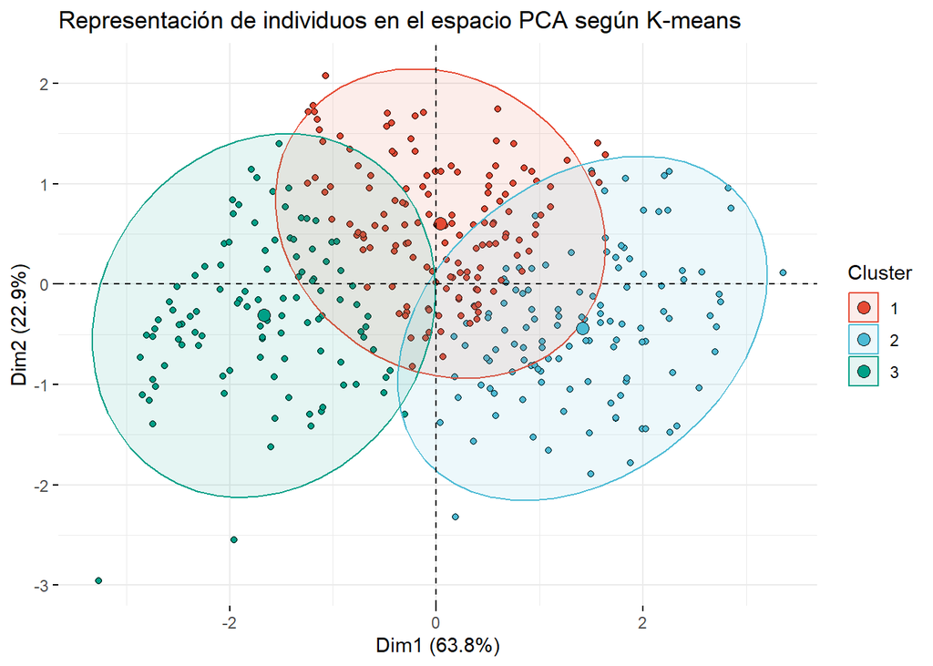

```r
# PCA con factoextra para representar los individuos y colorearlos por cluster
library(FactoMineR)
library(factoextra)

# Aplicamos PCA sobre los datos escalados
pca_res <- PCA(datos_cluster, graph = FALSE)

# Visualización con factoextra
fviz_pca_ind(pca_res,
             geom.ind = "point",
             pointshape = 21,
             fill.ind = datos_modelo_completo$cluster_kmeans,
             col.ind = "black",
             palette = "npg",
             addEllipses = TRUE,
             ellipse.level = 0.95,
             legend.title = "Cluster",
             repel = TRUE,
             title = "Representación de individuos en el espacio PCA según K-means")
```

El gráfico PCA muestra a cada día representado en un espacio bidimensional que explica el 86.7% de la variabilidad total. Se observan tres clusters bien definidos: el grupo 1 (rojo) está más concentrado, mientras que los grupos 2 (azul) y 3 (verde) presentan mayor dispersión. Aunque hay cierto solapamiento entre los clusters 1 y 2, las elipses muestran regiones diferenciadas. La primera dimensión parece asociarse al precio y volumen energético, mientras que la segunda refleja el balance de importación y exportación.

El análisis revela tres patrones energéticos claramente diferenciados, confirmados tanto numéricamente como visualmente. La segmentación en tres clusters permite identificar días normales, jornadas de alta demanda y días con exceso de energía exportada a bajo precio. Además, se observa una relación inversa entre precio y flujo energético: cuando el precio es bajo, se exporta gran cantidad de energía, mientras que en los días de precios altos se recurre a la importación. Este comportamiento sugiere una pérdida económica potencial, ya que vendemos barato y compramos caro. Esta clasificación resulta clave para la toma de decisiones estratégicas: facilita la planificación energética, la predicción de precios, la optimización de compra/venta y la identificación de oportunidades para energías renovables o almacenamiento inteligente.